# R Notebook

```r
diamonds <- read.delim("HW-diamonds.txt", header = FALSE, sep = "", dec = ".")
```

```r
head(diamonds)
```

|  | V1 | V2 | V3 | V4 | V5 |
| --- | --- | --- | --- | --- | --- |
| 1 | 0.30 | D | VS2 | GIA | 1302 |
| 2 | 0.30 | E | VS1 | GIA | 1510 |
| 3 | 0.30 | G | VVS1 | GIA | 1510 |
| 4 | 0.30 | G | VS1 | GIA | 1260 |
| 5 | 0.31 | D | VS1 | GIA | 1641 |
| 6 | 0.31 | E | VS1 | GIA | 1555 |

```r
colnames(diamonds) <- c("caratage", "purity", "clarity", "certificate", "price")
diamonds$purity <- factor(diamonds$purity, levels=c("D", "E", "F", "G", "H", "I"))
diamonds$clarity <- factor(diamonds$clarity, levels=c("VS2", "VS1", "VVS2", "VVS1", "IF"))
```

```r
summary(diamonds)
```

```
##     caratage      purity clarity   certificate     price
##  Min.   :0.1800   D:16   VS2 :53   GIA:151     Min.   :  638
##  1st Qu.:0.3500   E:44   VS1 :81   HRD: 79     1st Qu.: 1625
##  Median :0.6200   F:82   VVS2:78   IGI: 78     Median : 4215
##  Mean   :0.6309   G:65   VVS1:52               Mean   : 5019
##  3rd Qu.:0.8500   H:61   IF  :44               3rd Qu.: 7446
##  Max.   :1.1000   I:40                         Max.   :16008
```

```r
library(ggplot2)
```

### 1. Plot price vs caratage and log(price) vs caratage. Decide on which response variable is better to use

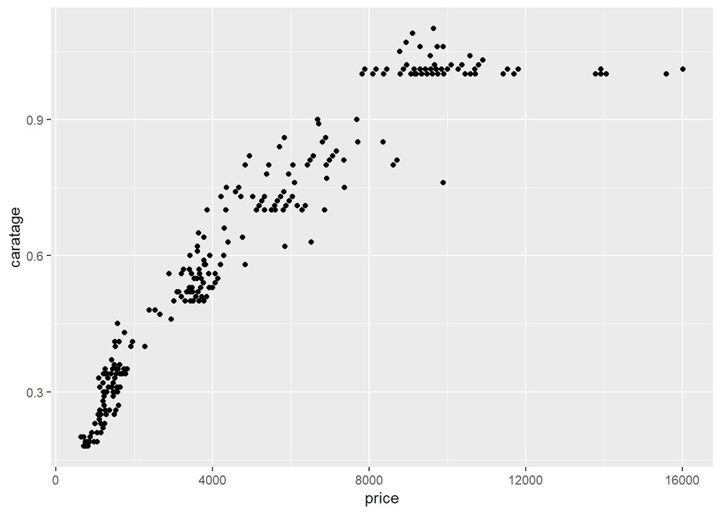

```r
ggplot(data=diamonds, aes(price, caratage)) +
        geom_point()
```

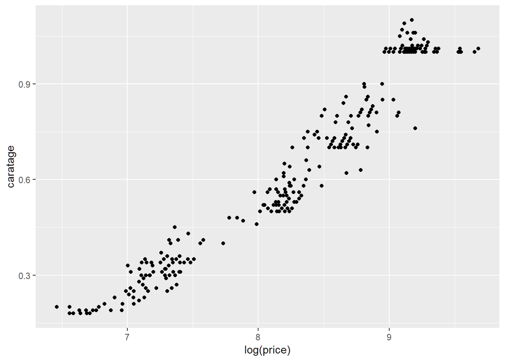

```r
ggplot(data=diamonds, aes(log(price), caratage)) +
        geom_point()
```

log(price) seems more linear (maybe different transformations?)

### 2. Find a suitable way to include, besides caratage, the other categorical information

available: clarity, color and certificate. Use the worst level of each categorical variable as the reference category and HRD for certification institution. Comment on the model fitted, and perform a basic analysis of the residuals (normality, constant variance, independence, you may also want to use the function outlierTest or residualPlot ).

```r
#Starting model
model.1.1<-lm(formula = price ~ caratage + purity + clarity + certificate, data = diamonds)
summary(model.1.1)
```

```
##
## Call:
## lm(formula = price ~ caratage + purity + clarity + certificate,
##     data = diamonds)
##
## Residuals:
##     Min      1Q  Median      3Q     Max
## -1740.0  -428.8  -128.3   314.3  3634.1
##
## Coefficients:
##                Estimate Std. Error t value Pr(>|t|)
## (Intercept)    -1622.83     247.65  -6.553 2.51e-10 ***
## caratage       12766.40     190.02  67.183  < 2e-16 ***
## purityE        -1439.09     207.98  -6.919 2.83e-11 ***
## purityF        -1841.69     195.23  -9.433  < 2e-16 ***
## purityG        -2176.67     200.39 -10.862  < 2e-16 ***
## purityH        -2747.15     202.91 -13.538  < 2e-16 ***
## purityI        -3313.10     212.71 -15.575  < 2e-16 ***
## clarityVS1       317.44     128.09   2.478   0.0138 *
## clarityVVS2      600.85     130.28   4.612 5.95e-06 ***
## clarityVVS1     1102.72     144.45   7.634 3.18e-13 ***
## clarityIF       1792.01     171.19  10.468  < 2e-16 ***
## certificateHRD    15.23     107.25   0.142   0.8872
## certificateIGI   141.26     128.26   1.101   0.2716
## ---
## Signif. codes:  0 '***' 0.001 '**' 0.01 '*' 0.05 '.' 0.1 ' ' 1
##
## Residual standard error: 710.4 on 295 degrees of freedom
## Multiple R-squared:  0.9581, Adjusted R-squared:  0.9564
## F-statistic: 562.5 on 12 and 295 DF,  p-value: < 2.2e-16
```

```r
#Let's try to predict log(price)
model.1.2<-lm(formula = log(price) ~ caratage + purity + clarity + certificate, data = diamonds)
summary(model.1.2)
```

```
##
## Call:
## lm(formula = log(price) ~ caratage + purity + clarity + certificate,
##     data = diamonds)
##
## Residuals:
##      Min       1Q   Median       3Q      Max
## -0.31236 -0.11520  0.01613  0.10833  0.36339
##
## Coefficients:
##                 Estimate Std. Error t value Pr(>|t|)
## (Intercept)     6.502651   0.048178 134.971  < 2e-16 ***
## caratage        2.855013   0.036968  77.230  < 2e-16 ***
## purityE        -0.029509   0.040461  -0.729  0.46638
## purityF        -0.106358   0.037981  -2.800  0.00544 **
## purityG        -0.206349   0.038985  -5.293 2.35e-07 ***
## purityH        -0.287876   0.039475  -7.293 2.81e-12 ***
## purityI        -0.416557   0.041382 -10.066  < 2e-16 ***
## clarityVS1      0.096609   0.024919   3.877  0.00013 ***
## clarityVVS2     0.201923   0.025344   7.967 3.56e-14 ***
## clarityVVS1     0.297835   0.028102  10.598  < 2e-16 ***
## clarityIF       0.298541   0.033303   8.964  < 2e-16 ***
## certificateHRD -0.008856   0.020864  -0.424  0.67155
## certificateIGI -0.182711   0.024952  -7.323 2.33e-12 ***
## ---
## Signif. codes:  0 '***' 0.001 '**' 0.01 '*' 0.05 '.' 0.1 ' ' 1
##
## Residual standard error: 0.1382 on 295 degrees of freedom
## Multiple R-squared:  0.9723, Adjusted R-squared:  0.9712
## F-statistic: 863.6 on 12 and 295 DF,  p-value: < 2.2e-16
```

```r
#model1.2 has a lower residual standard error and a higher R^2. We will predict log(price).

#By default, the category that R chooses to be the reference or baseline, is the first category that appears alphabetically or  numerically (if categories are coded using 0,1,2,...).
#Let's use the worst level of each categorical variable as the reference category and HRD for certification institution.
diamonds$purity <- relevel(diamonds$purity, ref = "I")
diamonds$clarity <- relevel(diamonds$clarity, ref = "VS2")
diamonds$certificate <- relevel(diamonds$certificate, ref = "HRD")
model.1.3<-lm(formula = log(price) ~ caratage + purity + clarity + certificate, data = diamonds)
summary(model.1.3)
```

```
##
## Call:
## lm(formula = log(price) ~ caratage + purity + clarity + certificate,
##     data = diamonds)
##
## Residuals:
##      Min       1Q   Median       3Q      Max
## -0.31236 -0.11520  0.01613  0.10833  0.36339
##
## Coefficients:
##                 Estimate Std. Error t value Pr(>|t|)
## (Intercept)     6.077239   0.048091 126.369  < 2e-16 ***
## caratage        2.855013   0.036968  77.230  < 2e-16 ***
## purityD         0.416557   0.041382  10.066  < 2e-16 ***
## purityE         0.387047   0.030824  12.557  < 2e-16 ***
## purityF         0.310198   0.027479  11.288  < 2e-16 ***
## purityG         0.210207   0.028359   7.412 1.32e-12 ***
## purityH         0.128681   0.028523   4.511 9.31e-06 ***
## clarityVS1      0.096609   0.024919   3.877  0.00013 ***
## clarityVVS2     0.201923   0.025344   7.967 3.56e-14 ***
## clarityVVS1     0.297835   0.028102  10.598  < 2e-16 ***
## clarityIF       0.298541   0.033303   8.964  < 2e-16 ***
## certificateGIA  0.008856   0.020864   0.424  0.67155
## certificateIGI -0.173855   0.028673  -6.063 4.07e-09 ***
## ---
## Signif. codes:  0 '***' 0.001 '**' 0.01 '*' 0.05 '.' 0.1 ' ' 1
##
## Residual standard error: 0.1382 on 295 degrees of freedom
## Multiple R-squared:  0.9723, Adjusted R-squared:  0.9712
## F-statistic: 863.6 on 12 and 295 DF,  p-value: < 2.2e-16
```

```r
#Same statistics as model1.2.

#Let's check the interactions.
model.1.4 <- lm(formula = log(price) ~ .^2, data = diamonds)
summary(model.1.4)
```

```
##
## Call:
## lm(formula = log(price) ~ .^2, data = diamonds)
##
## Residuals:
##       Min        1Q    Median        3Q       Max
## -0.223329 -0.075862  0.009005  0.067480  0.222220
##
## Coefficients:
##                             Estimate Std. Error t value Pr(>|t|)
## (Intercept)                 6.862282   0.137637  49.858  < 2e-16 ***
## caratage                    2.165783   0.131059  16.525  < 2e-16 ***
## purityD                     0.114329   0.209143   0.547  0.58511
## purityE                     0.006050   0.134666   0.045  0.96421
## purityF                    -0.015570   0.115000  -0.135  0.89241
## purityG                    -0.148842   0.119834  -1.242  0.21539
## purityH                    -0.233673   0.120309  -1.942  0.05325 .
## clarityVS1                  0.046445   0.099326   0.468  0.64048
## clarityVVS2                 0.118086   0.107712   1.096  0.27402
## clarityVVS1                -0.018461   0.140310  -0.132  0.89543
## clarityIF                  -0.233756   0.208476  -1.121  0.26327
## certificateGIA             -0.595596   0.105569  -5.642 4.61e-08 ***
## certificateIGI             -1.046488   0.148161  -7.063 1.66e-11 ***
## caratage:purityD            0.433686   0.176822   2.453  0.01488 *
## caratage:purityE            0.171950   0.118496   1.451  0.14802
## caratage:purityF            0.178748   0.102131   1.750  0.08133 .
## caratage:purityG            0.234160   0.104813   2.234  0.02638 *
## caratage:purityH            0.241760   0.108622   2.226  0.02694 *
## caratage:clarityVS1        -0.104669   0.082177  -1.274  0.20397
## caratage:clarityVVS2       -0.183182   0.092425  -1.982  0.04860 *
## caratage:clarityVVS1        0.037092   0.125042   0.297  0.76700
## caratage:clarityIF          0.409186   0.199299   2.053  0.04112 *
## caratage:certificateGIA     0.521739   0.094034   5.548 7.44e-08 ***
## caratage:certificateIGI     1.246025   0.106120  11.742  < 2e-16 ***
## purityD:clarityVS1          0.081642   0.116729   0.699  0.48496
## purityE:clarityVS1          0.148622   0.074010   2.008  0.04572 *
## purityF:clarityVS1          0.102517   0.066709   1.537  0.12563
## purityG:clarityVS1          0.180805   0.074760   2.418  0.01631 *
## purityH:clarityVS1          0.129919   0.070648   1.839  0.06713 .
## purityD:clarityVVS2         0.012386   0.132609   0.093  0.92566
```

[output cut: 23 more lines]

```
## purityH:certificateIGI     -0.109104   0.099536  -1.096  0.27410
## clarityVS1:certificateGIA   0.024094   0.048846   0.493  0.62226
## clarityVVS2:certificateGIA  0.125066   0.047353   2.641  0.00879 **
## clarityVVS1:certificateGIA  0.171132   0.052978   3.230  0.00141 **
## clarityIF:certificateGIA    0.109236   0.082454   1.325  0.18647
## clarityVS1:certificateIGI  -0.088204   0.111572  -0.791  0.42996
## clarityVVS2:certificateIGI  0.122509   0.097623   1.255  0.21070
## clarityVVS1:certificateIGI  0.205088   0.107006   1.917  0.05645 .
## clarityIF:certificateIGI    0.415481   0.138042   3.010  0.00289 **
## ---
## Signif. codes:  0 '***' 0.001 '**' 0.01 '*' 0.05 '.' 0.1 ' ' 1
##
## Residual standard error: 0.1052 on 246 degrees of freedom
## Multiple R-squared:  0.9866, Adjusted R-squared:  0.9833
## F-statistic: 297.5 on 61 and 246 DF,  p-value: < 2.2e-16
```

```r
#The standard error decreases  and th R^2 increases. However, only some interactions are relevant. Let's keep only those.

model.1.5 <- lm(formula = log(price) ~ caratage + purity + clarity + certificate + caratage:purity + caratage:clarity + caratage:certificate, data = diamonds)
summary(model.1.5)
```

```
##
## Call:
## lm(formula = log(price) ~ caratage + purity + clarity + certificate +
##     caratage:purity + caratage:clarity + caratage:certificate,
##     data = diamonds)
##
## Residuals:
##      Min       1Q   Median       3Q      Max
## -0.29748 -0.08012  0.01170  0.07622  0.24985
##
## Coefficients:
##                         Estimate Std. Error t value Pr(>|t|)
## (Intercept)              6.50514    0.08474  76.765  < 2e-16 ***
## caratage                 2.34980    0.10562  22.248  < 2e-16 ***
## purityD                  0.20231    0.08120   2.492 0.013289 *
## purityE                  0.28078    0.06255   4.489 1.04e-05 ***
## purityF                  0.17913    0.05622   3.186 0.001602 **
## purityG                  0.02068    0.05606   0.369 0.712532
## purityH                 -0.06277    0.06031  -1.041 0.298876
## clarityVS1               0.16228    0.05684   2.855 0.004622 **
## clarityVVS2              0.40939    0.06227   6.575 2.33e-10 ***
## clarityVVS1              0.44123    0.07020   6.286 1.23e-09 ***
## clarityIF                0.45026    0.06894   6.531 3.00e-10 ***
## certificateGIA          -0.30085    0.06501  -4.628 5.62e-06 ***
## certificateIGI          -0.83161    0.06643 -12.518  < 2e-16 ***
## caratage:purityD         0.34778    0.10883   3.196 0.001553 **
## caratage:purityE         0.12456    0.08557   1.456 0.146594
## caratage:purityF         0.15443    0.07562   2.042 0.042062 *
## caratage:purityG         0.24303    0.07695   3.158 0.001757 **
## caratage:purityH         0.22182    0.08000   2.773 0.005923 **
## caratage:clarityVS1     -0.09237    0.07485  -1.234 0.218162
## caratage:clarityVVS2    -0.29023    0.08134  -3.568 0.000422 ***
## caratage:clarityVVS1    -0.20919    0.09474  -2.208 0.028051 *
## caratage:clarityIF      -0.06130    0.10481  -0.585 0.559057
## caratage:certificateGIA  0.35249    0.08042   4.383 1.65e-05 ***
## caratage:certificateIGI  1.08590    0.09422  11.525  < 2e-16 ***
## ---
## Signif. codes:  0 '***' 0.001 '**' 0.01 '*' 0.05 '.' 0.1 ' ' 1
##
## Residual standard error: 0.1067 on 284 degrees of freedom
## Multiple R-squared:  0.9841, Adjusted R-squared:  0.9828
## F-statistic: 764.5 on 23 and 284 DF,  p-value: < 2.2e-16
```

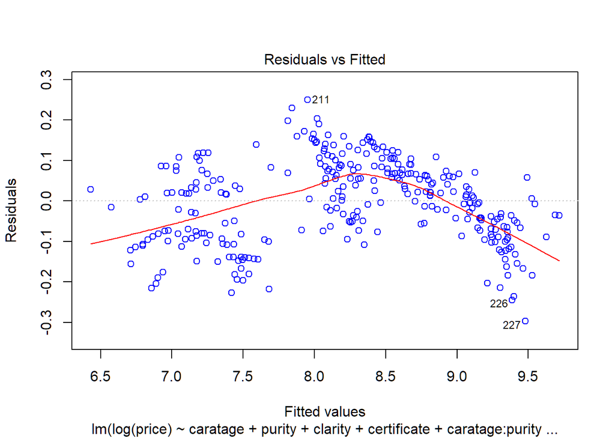

```r
#model.1.5 shows slightly worse statistics than model.1.4 but is way simpler.

#Let's analyse this model deeper.
# Residuals vs Fitted Plot
residuals_vs_fitted<-plot(model.1.5, which=1, col=c("blue"))
```

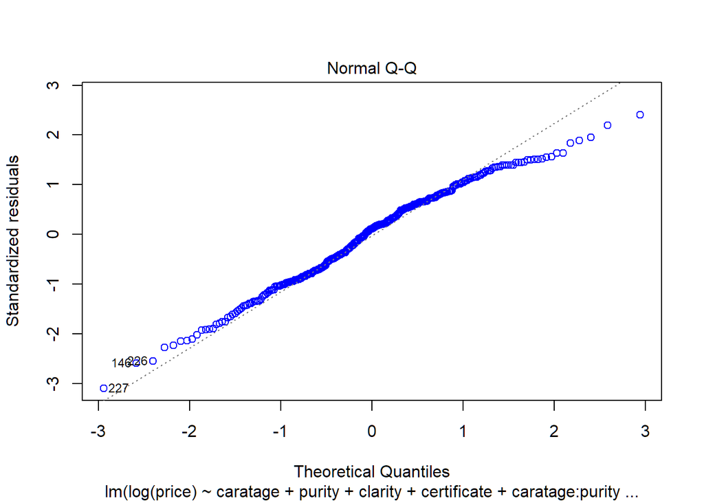

```r
#Normal Q-Q Plot
qq_plot<-plot(model.1.5, which=2, col=c("blue"))
```

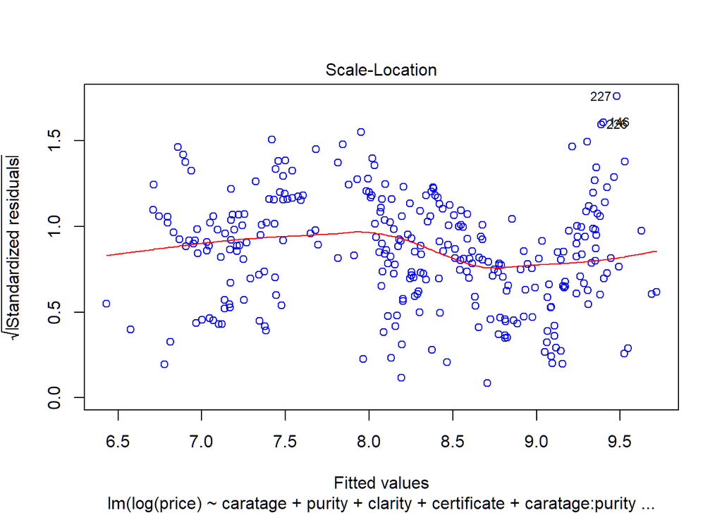

```r
#Scale-Location
residuals_vs_fitted<-plot(model.1.5, which=3, col=c("blue"))
```

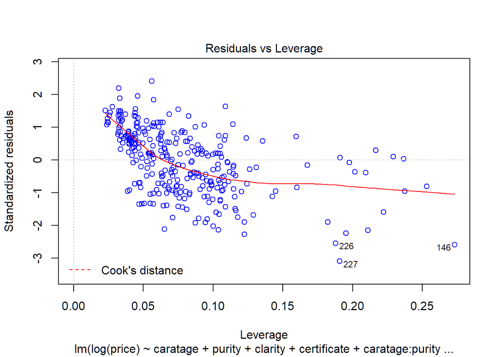

```r
#Residuals vs Leverage
residuals_vs_fitted<-plot(model.1.5, which=5, col=c("blue"))
```

### 3. Try two different remedial actions:

### 3a. Create a new categorical variable to segregate the stones according to caratage: let’s say less than 0.5 carats small, 0.5 to less than 1 carat (medium) and 1 carat and over (large). Make small as the reference category. Add this new variable to the existing model as well as an interaction term between this new variable and caratage.

- Is this regression model satisfactory? Are the standard assumptions of linear regression validated? Are the numerical estimates sensible?
- Interpret the interaction parameter med*carat. What can we infer on the incremental pricing of caratage in the 3 clusters?
- Which is more highly valued: colour or clarity?
- All other things being equal, what is the average price difference between a grade D diamond and another one graded (a) I (b) E?
- All other things being equal, are there price differences amongst the stones appraised by the GIA, IGI and HRD?

### 3b. Include the square of carat as a new explanatory variable. It avoids the subjectivity of clusters definition.

### 4. Which of the two remedial actions do you prefer and why? Think on terms of interpretability and validity of the assumptions.